# Exploring Montana fires with MTBS and PRISM climate data

Author

Travis Belote

Published

January 20, 2025

## Introduction

Fire plays a critical role in ecosystems of Montana, influencing both nature and society. We will be pulling in several different kinds of data to explore patterns of fire size, total area burned, fire severity, and climate in Montana. Data from the Monitoring Trends in Burn Severity (MTBS) program are available at https://www.mtbs.gov/. Researchers use remotely sensed data to estimate fire severity by looking at the difference between conditions before and after a fire. They then classify these data into 5 severity classes: un-burned = dark green; low severity = light green, moderate severity = yellow; high severity = red; increased greenness = not shown in below). The example below is from the Bridger Foothills fire in September 2020.

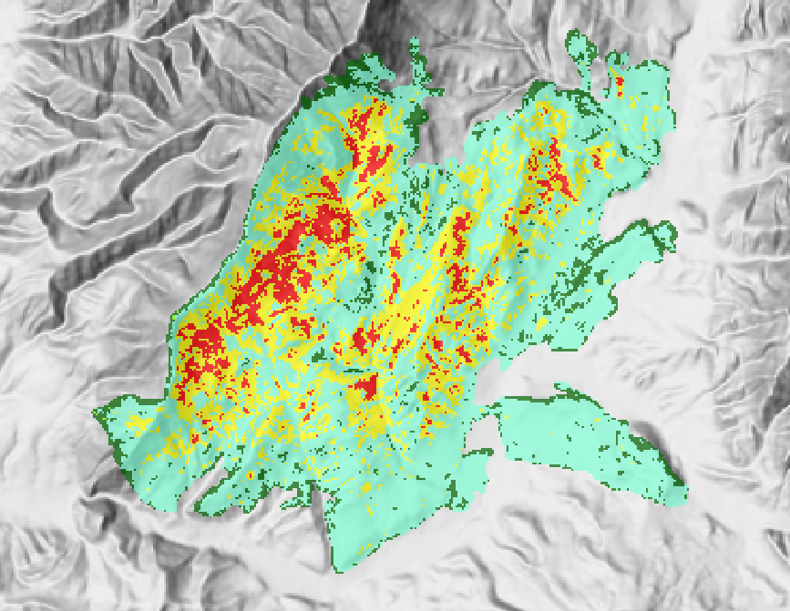

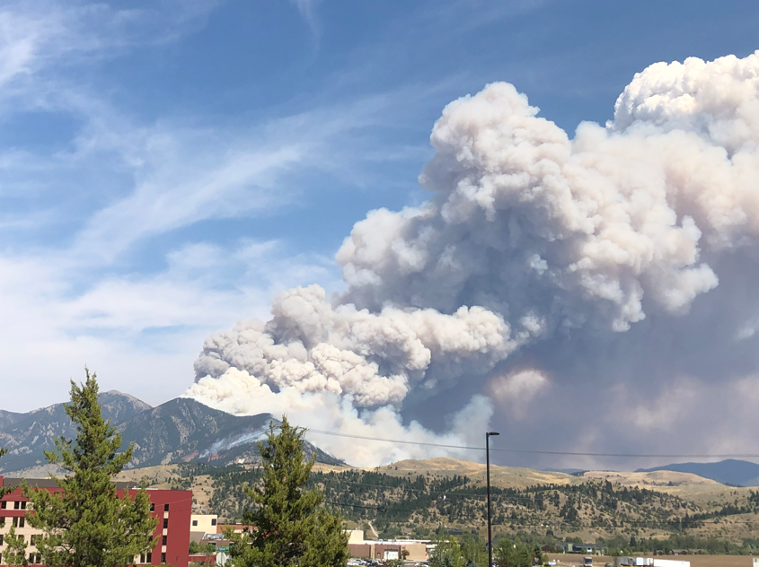

For this demo, we will ask: (1) Which places in Montana have experienced the most fires since 1984? (2) How are fire sizes distributed? Do they follow a normal distribution, or a more skewed distribution? Do many small fires burn as much area as a few large fires? (3) How has area burned and the proportion burned as high severity varied over time? (4) What is the relationship between climate (focusing on precipitation) and total area burned and firer severity?

Before bringing in and analyzing data, we need to load our libraries. Here, I’m using the `terra` and `sf` packages to work with spatial data and several packages (`dplyr` and `gglot)` within the `tidyverse`.

```r
library(terra)
library(sf)
library(tidyverse)
```

We will be working with 3 primary forms of data: vector data (polygons of fires), tabular data (in a spreadsheet), and raster data (PRISM climate data). Let’s start with bringing in fire perimeters from MTBS data, clipping it to Montana, recalculating area for each fire, plotting the data, and considering the consequences of the patterns.

Note: I use “pipes” which look like this %>%. This makes code more readable and can be read like a sentence. The beginning of a pipe (the object) is like the subject of a sentence and the functions are like the verbs. This structure makes the code easier to read. I don’t always use this approach, but do when I can.

## **Which places in Montana have experienced the most fire?**

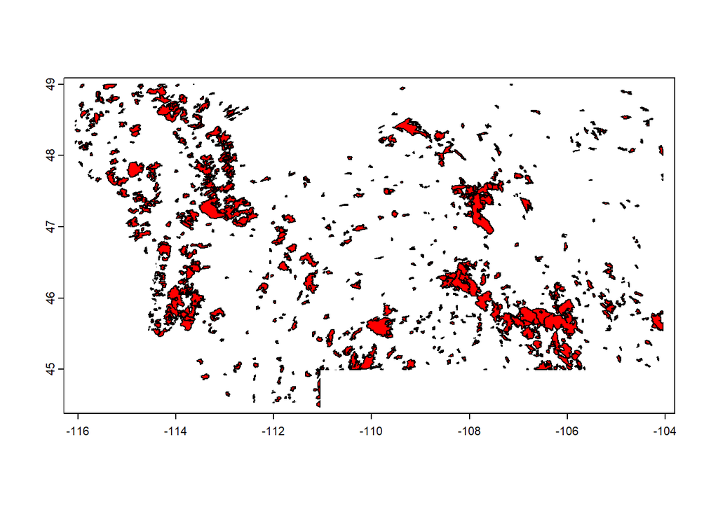

```r
# use vect from the terra package to read in the shapefile
MTfires_100kmBuffer <- vect("C:/Users/tbelote/TWS Dropbox/Travis Belote/MT_fire_demo/Montana_MTBS_fires_1948_2024.shp")

# Load in a map of the boundary of Montana
mt <- vect("C:/Users/tbelote/TWS Dropbox/Travis Belote/MT_fire_demo/Montana.shp")

# The two datasets do not have the same coorrdinate reference system (crs)
# Project the map of Montana to the same coordinate system as the fire data
mt_prj1 <- mt %>% terra::project(MTfires_100kmBuffer)

# use the new projected boundary of Montana to "clip" the fire data that includes
# some of Idaho and Wyoming; here I'm using "intersect" from the terra package
MT_fires <- MTfires_100kmBuffer %>% terra::intersect(mt_prj1)

# look at the map of Montana fires
terra::plot(MT_fires, col = "red")
```

**From the map above, describe the geographic distribution of fires? Based on what you know about Montana’s geography, which places have experienced the most fire? Which places have experienced the least fire?**

Some fires straddled the state borders, so we need to recalculate total area so that the area in the tabular data match the area in the spatial data. We need to reproject to an projection that minimizes distoration, so I’m going back to the original projection of Montana.

```r
MT_fires_prj <- MT_fires %>% project(mt)

# I'm using 'expanse' to calculate area (square km) for each polygon

MT_fires_prj$calc_area_km2 <- expanse(MT_fires_prj, unit = "km")
```

## Fire size distributions

The size of fires obviously has a large affect on ecosystems and human communities. Understanding the factors that govern the size of fires has been the topic of much research. Scientists have studied how fire sizes are influenced by the continuity of fuels, long-term and broad-scale climate, and daily weather events. Forests with contiguous interlocking tree canopies have been described as “contagious landscapes” where a fire can easily spread. Creating heterogeneity in the canopy is a goal to enhance forest resilience. Long-term increases in temperature and decreases in precipitation create dry conditions and can lead to bigger fire years. Daily wind events can also play a huge role in fire spread.

Let’s look at the distributions of fire sizes in Montana from 1984 to 2024.

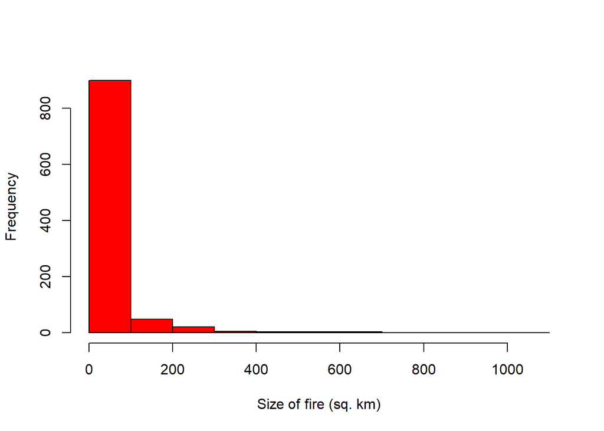

```r
# Let's look at a histogram of the burned area.
# We can do this very easily using hist()
hist(MT_fires_prj$calc_area_km2, col = "red",
     xlab=("Size of fire (sq. km)"), main = NA) #x-axis label and remove main title
```

There are lots of small fires and a few big ones, as we might expect. The size of fires is definitely not normally distributed.

It might be interesting to look at a how the distribution of fire sizes vary by year, so I’m going to move over to ggplot and use “facet_wrap” which will create a new histogram for each year. ggplot wants the data as a dataframe, so I have to use “as.data.frame” as the first step.

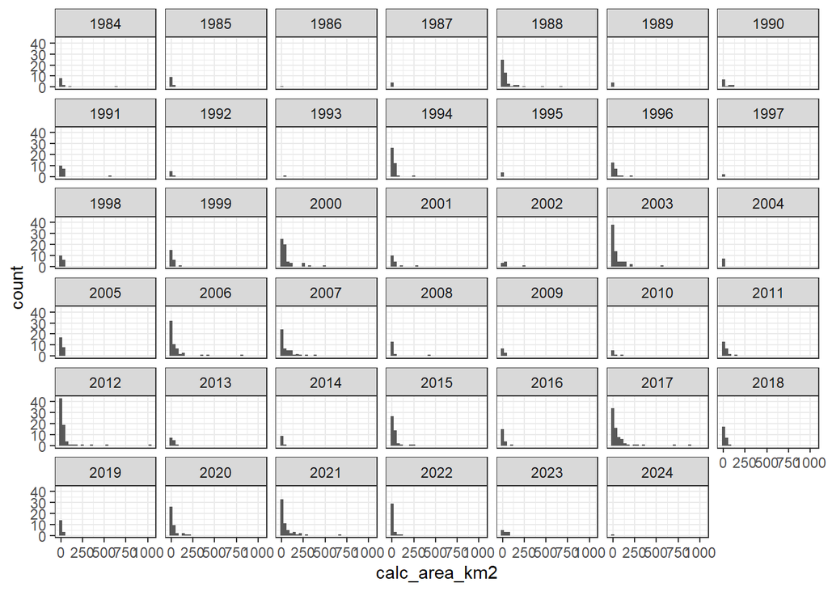

```r
MT_fires_prj %>% as.data.frame() %>%
  ggplot() + geom_histogram(aes(calc_area_km2)) + facet_wrap("year") + theme_bw()
```

### Pareto Principle and “80/20 Rule” applied to fires

I find the Pareto Principle, which colloquially has been called the 80/20 rule, fascinating. There are many phenomena where an important few (top 20% of instances) have a disproportionate (i.e., 80%) affect on an outcome. This has been applied to business (20% of customers generate 80% of revenues), our daily lives (we wear 20% of our clothes 80% of the time), to ecosystems (20% of the species contribute 80% of the biomass).

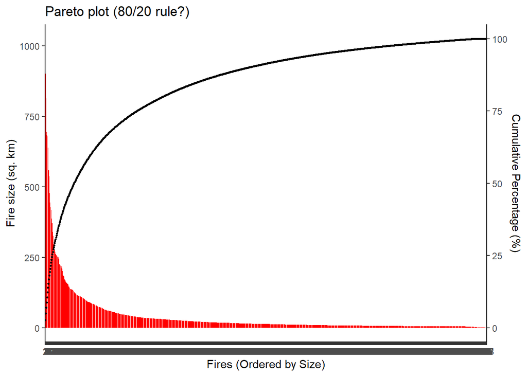

```r
# Prepare data: Calculate cumulative percentages and sort explicitly
MT_fires_df <- as.data.frame(MT_fires_prj) %>%
  arrange(desc(calc_area_km2)) %>%
  mutate(fire_order = factor(row_number(), levels = row_number()), # Explicit order
    cumulative_area = cumsum(calc_area_km2),
    cumulative_percentage = cumulative_area / sum(calc_area_km2) * 100)

# Create Pareto plot
ggplot(MT_fires_df, aes(x = fire_order)) +
  geom_bar(aes(y = calc_area_km2), stat = "identity", fill = "red") +
  geom_point(aes(y = cumulative_percentage / 100 * max(calc_area_km2)),
             color = "black", cex = 0.5) +
  scale_y_continuous(name = "Fire size (sq. km)",
    sec.axis = sec_axis(~ . / max(MT_fires_df$calc_area_km2) * 100,
                        name = "Cumulative Percentage (%)")) +
  labs(title = "Pareto plot (80/20 rule?)", x = "Fires (Ordered by Size)",
       y = NULL) +
  theme(axis.text.x = element_blank(), axis.ticks.x = element_blank()) +
    theme_classic()
```

## Fire size and severity through time

Fire sizes are important, but so is understanding the severity of fires. I’ve already downloaded fire severity data for Montana for the years 1984 to 2024 and calculated the proportion of each fire classified into different fire severity classes. I created a spreadsheet with these data called “MTBS_area_by_class.csv” in your folder.

We need to load in the spreadsheet with fire severity class, area burned, proportion of fire, and year.

```r
severity <- read.csv("C:/Users/tbelote/TWS Dropbox/Travis Belote/MT_fire_demo/MTBS_area_by_class.csv")

# Now, let's take a look at the top of the data
head(severity)
```

```
  Class Area_km2  Proportion year
1    NA   0.0000 0.000000000 1984
2     1 232.5006 0.248691006 1984
3     2 403.1460 0.431219465 1984
4     3 172.5318 0.184546220 1984
5     4 116.2467 0.124341652 1984
6     5   6.4836 0.006935092 1984
```

Let’s once again start with focusing on total area burned. In the exercise above, we plotted fire sizes and fire sizes by year, but let’s use these data to plot how annual total area burned varies over across years. We first need to sum the total area of fires by year. Here we taking the data severity and going to summarize total burned area by year. We first need to group by year and the sum the total area to create a new variable called “TAB”.

```r
total_area <- severity %>% group_by(year) %>% summarize(TAB = sum(Area_km2))
print(total_area)
```

```
# A tibble: 40 × 2
    year     TAB
   <int>   <dbl>
 1  1984  931.
 2  1985  236.
 3  1986    5.04
 4  1987   28.3
 5  1988 6565.
 6  1989   37.2
 7  1990  399.
 8  1991  852.
 9  1992   69.5
10  1994  902.
# ℹ 30 more rows
```

Now that we have these data summarized, we want to create a plot of total area burned (TAB) across years. We’re going to use ggplot2, which is part of the tidyverse. We’re going to use pipes again to start this line of code. `geom_line` tells R to make a line of the data with `year` on the x-axis and `TAB` on the y-axis. `aes` means aesthetics mapping and describes the visual properties to be graphed.

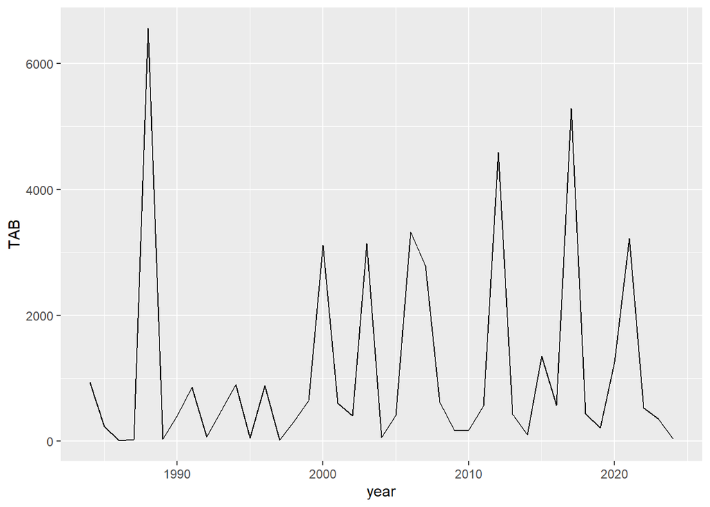

```r
total_area %>% ggplot() + geom_line(aes(x = year, y = TAB))
```

That looks okay, but I want to customize the plot by turning the line red, removing the grey background, and make the y-axis label more meaningful.

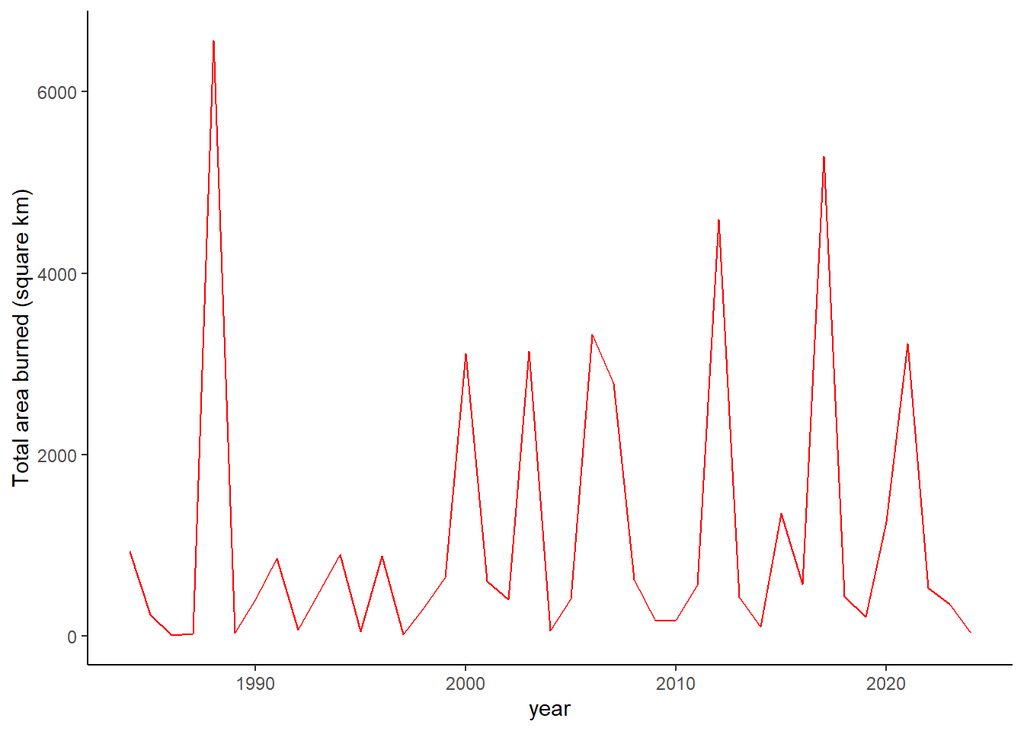

```r
total_area %>% ggplot() + geom_line(aes(x = year, y = TAB), color = "red") +
  theme_classic() +
  ylab("Total area burned (square km)")
```

That looks better.

**What do you notice about these patterns? Do you remember any of those “peak” years?**

[figure not shown]

Check out the front page of the Billings Gazette in July 1988.

## Proportion high severity

Now that we’ve looked at total area burned I really want to focus on high severity fire for this exercise, so let’s filter the data where Class is equal to 4 (high severity) and drop the NAs. We’re going to create a new object called `high_severity` that only includes the high severity area and proportions.

```r
high_severity <- severity %>% filter(Class == 4) %>% drop_na()
print(high_severity)
```

```
   Class  Area_km2  Proportion year
1      4  116.2467 0.124341652 1984
2      4   57.5379 0.243806727 1985
3      4    0.5157 0.102357985 1986
4      4    0.5211 0.018409004 1987
5      4 1874.1717 0.283290046 1988
6      4    0.8514 0.022913891 1989
7      4   32.4369 0.080019805 1990
8      4   36.1278 0.042226912 1991
9      4    1.6533 0.023715160 1992
10     4   82.8063 0.091313474 1994
11     4    0.4491 0.009718381 1995
12     4  105.6186 0.119430782 1996
13     4   58.7412 0.189819743 1998
14     4   14.4900 0.022486913 1999
```

[output cut: 25 more lines]

Now, let’s take this subset of the data and plot the proportion of all fires that were classified as high severity across year. I’m going to multiply `Proportion` by 100 to represent the data as a percentage.

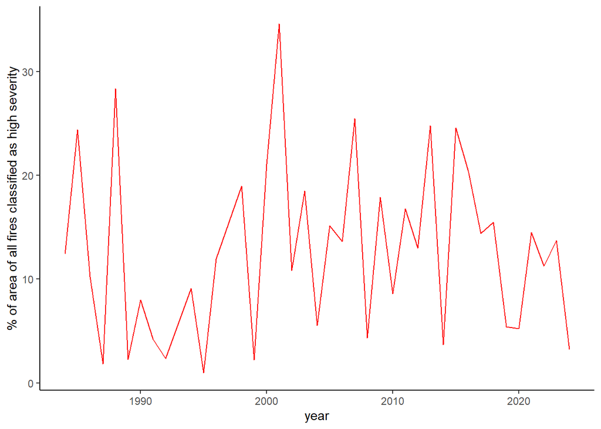

```r
high_severity %>% ggplot() + geom_line(aes(x = year, y = Proportion*100), color = "red") +
  theme_classic() +
  ylab("% of area of all fires classified as high severity")
```

**What do you notice about how the percent of fires classified as high severity vary by year? Are the same years with the highest total are burned also the years with the highest percentage of high severity fire?**

## Climate and fire

We know that the total area burned and the % of fires classified as high severity vary from year to year? What might explain these patterns? We’ll investigate the possible relationship between total area burned and total precipitation. I’ve already downloaded PRISM precipitation data for the lower 48 states. PRISM stands for Parameter-elevation Regressions on Independent Slopes Model - and is a type of climate data widely used - but be careful because there are critics of its approach to downscaling climate data. Explore the data here: https://prism.oregonstate.edu/

We’re going to bring the annual precipitation (mm) into R and then clip out on the data for Montana. I will be reading in the annual precipitation data for Montana using `rast` from the `terra` package and “stacking” the rasters. Stacking rasters with the same resolution, extent, and coordinate system is a very powerful way to analyze spatial data. Since there are many datasets listed in “ppt_files” `rast` will create a stack of layers.

```r
# Set the directory where the .bil files are stored
ppt_dir <- "C:/Users/tbelote/TWS Dropbox/Travis Belote/PRISM_r/annual_ppt_1984_2023"

# Get a list of all .bil files in the directory
ppt_files <- list.files(list.files(ppt_dir, pattern = "bil$", full.names = TRUE),
                        pattern = "bil$", full.names = TRUE)

# Load the .bil files into a SpatRaster stack (to work with them as a time series)
ppt_stack <- rast(ppt_files)

# Load in a map of the boundary of Montana
mt <- st_read("C:/Users/tbelote/TWS Dropbox/Travis Belote/MT_fire_demo/Montana.shp")
# The shapefile of Montana that I use is in a different projection than the PRISM
# data. We will project the map of Montana to the same coordinate system as the
# PRISM data using st_transform.
mt <- st_transform(mt, crs = crs(ppt_stack))

# Now, clip the PRISM data out for just Montana
ppt_MT <- ppt_stack %>% crop(mt) %>% mask(mt) %>% trim()

# Let's look at the names.
names(ppt_MT)
```

```
 [1] "PRISM_ppt_stable_4kmM3_1984_bil" "PRISM_ppt_stable_4kmM3_1985_bil"
 [3] "PRISM_ppt_stable_4kmM3_1986_bil" "PRISM_ppt_stable_4kmM3_1987_bil"
 [5] "PRISM_ppt_stable_4kmM3_1988_bil" "PRISM_ppt_stable_4kmM3_1989_bil"
 [7] "PRISM_ppt_stable_4kmM3_1990_bil" "PRISM_ppt_stable_4kmM3_1991_bil"
 [9] "PRISM_ppt_stable_4kmM3_1992_bil" "PRISM_ppt_stable_4kmM3_1993_bil"
[11] "PRISM_ppt_stable_4kmM3_1994_bil" "PRISM_ppt_stable_4kmM3_1995_bil"
[13] "PRISM_ppt_stable_4kmM3_1996_bil" "PRISM_ppt_stable_4kmM3_1997_bil"
[15] "PRISM_ppt_stable_4kmM3_1998_bil" "PRISM_ppt_stable_4kmM3_1999_bil"
[17] "PRISM_ppt_stable_4kmM3_2000_bil" "PRISM_ppt_stable_4kmM3_2001_bil"
[19] "PRISM_ppt_stable_4kmM3_2002_bil" "PRISM_ppt_stable_4kmM3_2003_bil"
[21] "PRISM_ppt_stable_4kmM3_2004_bil" "PRISM_ppt_stable_4kmM3_2005_bil"
[23] "PRISM_ppt_stable_4kmM3_2006_bil" "PRISM_ppt_stable_4kmM3_2007_bil"
[25] "PRISM_ppt_stable_4kmM3_2008_bil" "PRISM_ppt_stable_4kmM3_2009_bil"
[27] "PRISM_ppt_stable_4kmM3_2010_bil" "PRISM_ppt_stable_4kmM3_2011_bil"
[29] "PRISM_ppt_stable_4kmM3_2012_bil" "PRISM_ppt_stable_4kmM3_2013_bil"
[31] "PRISM_ppt_stable_4kmM3_2014_bil" "PRISM_ppt_stable_4kmM3_2015_bil"
[33] "PRISM_ppt_stable_4kmM3_2016_bil" "PRISM_ppt_stable_4kmM3_2017_bil"
[35] "PRISM_ppt_stable_4kmM3_2018_bil" "PRISM_ppt_stable_4kmM3_2019_bil"
[37] "PRISM_ppt_stable_4kmM3_2020_bil" "PRISM_ppt_stable_4kmM3_2021_bil"
[39] "PRISM_ppt_stable_4kmM3_2022_bil" "PRISM_ppt_stable_4kmM3_2023_bil"
```

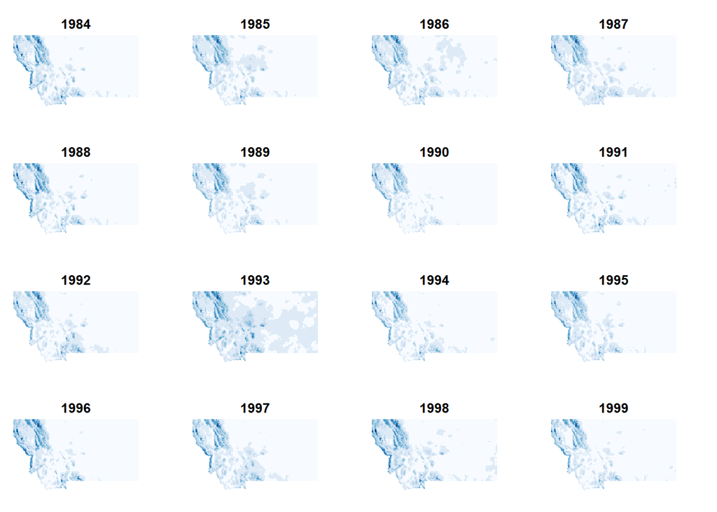

```r
# Those are kinda ugly (i.e., have a lot of unnecessary information),
# so we'll use 'str_sub' to grab just the years.
names(ppt_MT) <- str_sub(names(ppt_MT), start = -8, end = -5)

# Plot the first few layers
plot(ppt_MT, col = blues9, legend = F, axes = F, box = F)
```

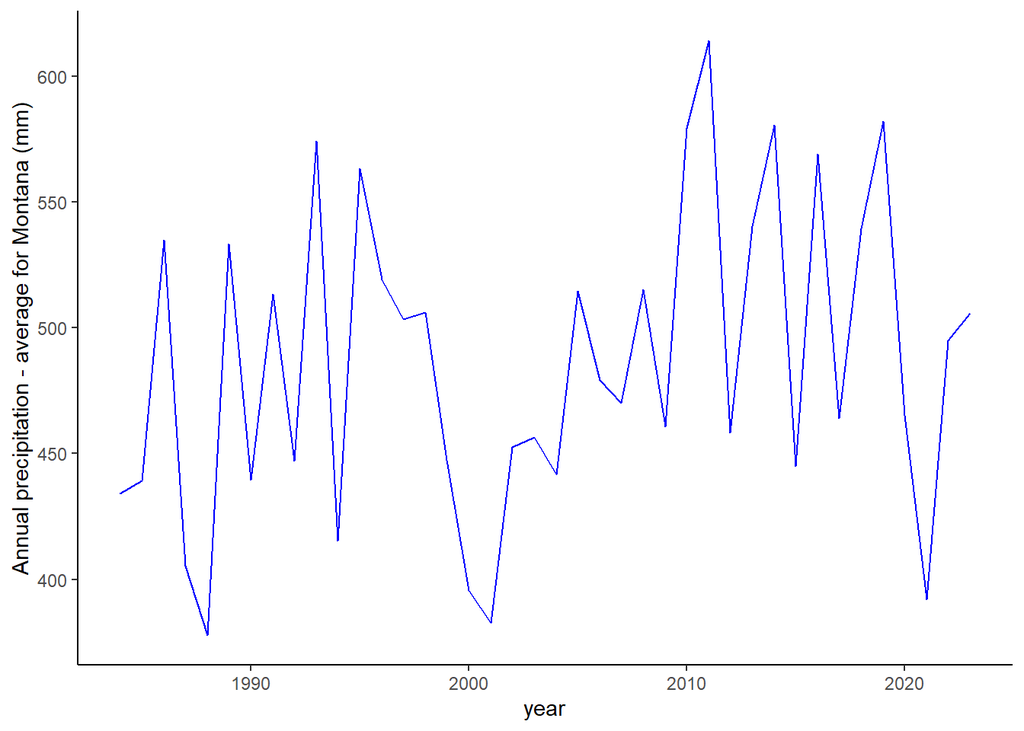

```r
# Calculate the mean annual precipitation for Montana
mean_ppt <- ppt_MT %>% global(stat = "mean", na.rm = TRUE) %>% as.data.frame()

# The approach above makes year the row name (not a column in the data),
# so I need to use rownames_to_column() to make year a variable.
# I also want to turn it into a number so I can use year as a
# quantitative variable for plotting.
annual_ppt <- rownames_to_column(mean_ppt, var = "year")
annual_ppt$year <- as.numeric(annual_ppt$year)

# Finally, let's plot how annual precipitation (averaged across Montana)
# varies year-to-year.
annual_ppt %>% ggplot() +
  geom_line(aes(x = year, y = mean), color = "blue") +
  theme_classic() +
  ylab("Annual precipitation - average for Montana (mm)")
```

We now have year, total area burned, the proportion of fire classified as high severity, and annual precipitation across Montana. We want to explore some climate-fire relationships, but we need to join these data up. Luckily, our data all correspond to Montana, and all datasets include year as a variable. We’ll need to `join` these data together. Joining data in a relational database is a very powerful approach to asking novel research questions with existing datasets.

**Before you run this code, what would you predict the relationship between annual precipitation and total area burned might be? What about annual precipitation and proportion of fires that burned as high severity?**

```r
# "You can "pipe" together two left_join functions to add annual_ppt to our
# total area burned data, then add high_severity.
tab_high_sev_ppt <- total_area %>% left_join(annual_ppt, by = 'year') %>%
  left_join(high_severity, by = "year")

print(tab_high_sev_ppt)
```

```
# A tibble: 40 × 6
    year     TAB  mean Class Area_km2 Proportion
   <dbl>   <dbl> <dbl> <int>    <dbl>      <dbl>
 1  1984  931.    434.     4  116.        0.124
 2  1985  236.    439.     4   57.5       0.244
 3  1986    5.04  535.     4    0.516     0.102
 4  1987   28.3   405.     4    0.521     0.0184
 5  1988 6565.    378.     4 1874.        0.283
 6  1989   37.2   533.     4    0.851     0.0229
 7  1990  399.    440.     4   32.4       0.0800
 8  1991  852.    513.     4   36.1       0.0422
 9  1992   69.5   447.     4    1.65      0.0237
10  1994  902.    415.     4   82.8       0.0913
# ℹ 30 more rows
```

```r
# Let's look at the names to (a) make sure left_join did what we wanted it to do,
# and (b) see if we want to edit.
head(tab_high_sev_ppt)
```

```
# A tibble: 6 × 6
   year     TAB  mean Class Area_km2 Proportion
  <dbl>   <dbl> <dbl> <int>    <dbl>      <dbl>
1  1984  931.    434.     4  116.        0.124
2  1985  236.    439.     4   57.5       0.244
3  1986    5.04  535.     4    0.516     0.102
4  1987   28.3   405.     4    0.521     0.0184
5  1988 6565.    378.     4 1874.        0.283
6  1989   37.2   533.     4    0.851     0.0229
```

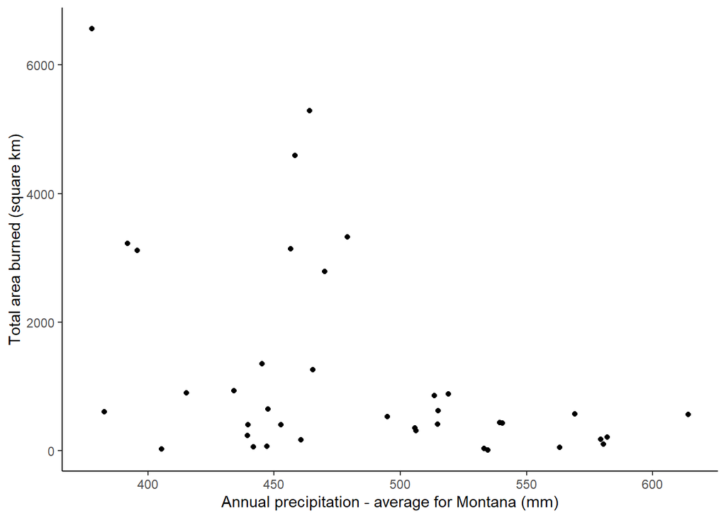

```r
# I don't like annual precipitation averaged acorss all of Montana being called
# "mean". That's confusing.
# So, let's rename it. Also "Proportion" isn't ambiguous. Let's rename it too.
# We can simply assign new "names" like this.
names(tab_high_sev_ppt) <- c("year", "TAB", "total_ppt", "class", "Area_km2", "high_severity_pct")

# Now, let's plot the relationship between annual precipitation and total area burned
tab_high_sev_ppt %>% drop_na() %>% ggplot() + geom_point(aes(x = total_ppt, y = TAB)) +
  theme_classic() +
  ylab("Total area burned (square km)") +
  xlab("Annual precipitation - average for Montana (mm)")
```

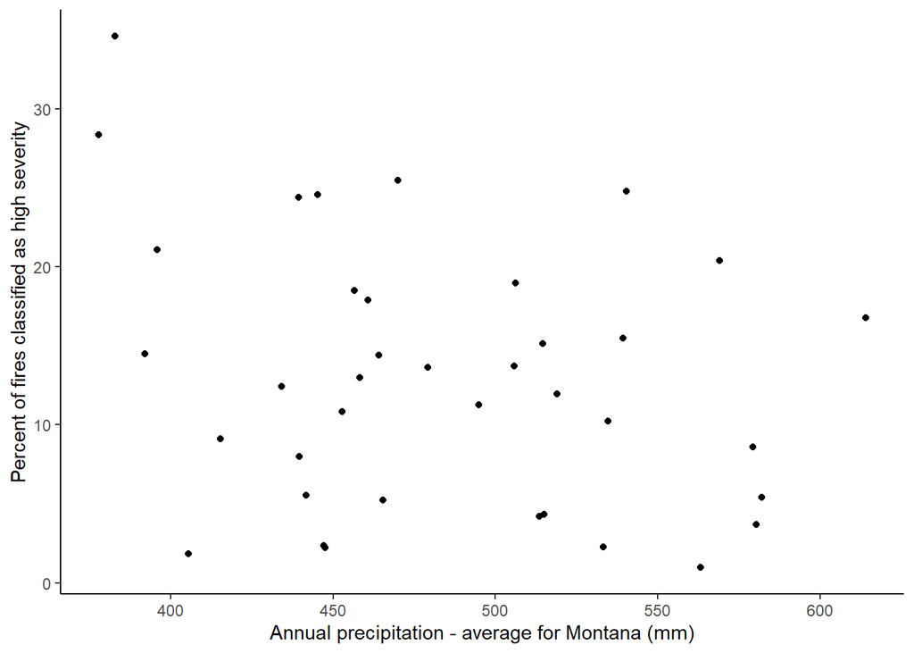

```r
# How about plotting annual precipitation and the proportion of fire
# classified as high severity
tab_high_sev_ppt %>% drop_na() %>% ggplot() + geom_point(aes(x = total_ppt, y = high_severity_pct*100)) +
  theme_classic() +
  ylab("Percent of fires classified as high severity") +
  xlab("Annual precipitation - average for Montana (mm)")
```

**How do these patterns compare to your predictions? What would your conclusions be? What else might you investigate? What other information would you need to feel good about your conclusions? Hint: think about how much information we lost by focusing on the entire state of Montana and only looking at climate data for each year (i.e., not considering seasons)? We simplified things a lot, probably too much. What other datasets would you want to explore before drawing conclusions about the relationship between climate and fires?**